# Course 5 - Project 1 - Step Counter

BRecon99

2024-09-05

## Loading and Preporcessing the Data

Show any code that is needed to

1. Load the data (i.e. read.csv())
2. Process/transform the data (if necessary) into a format suitable for your analysis

```r
library(data.table)
library(dplyr)
activity <- data.table::as.data.table(read.csv(file = "activity.csv"))
```

### What is mean total number of steps taken per day?

```r
# First lets combine all the equal dates into one, by summing the numeric values.
Combined <- activity %>%
  group_by(date) %>%
  summarise(across(where(is.numeric), sum))
```

```r
#Now we have the total steps per day, lets just take the total mean of steps in the 61 day interval:

mean_daily_steps <- mean(Combined$steps, na.rm = TRUE)
mean_daily_steps
```

[1] 10766.19

### Calculate the total number of steps taken per day

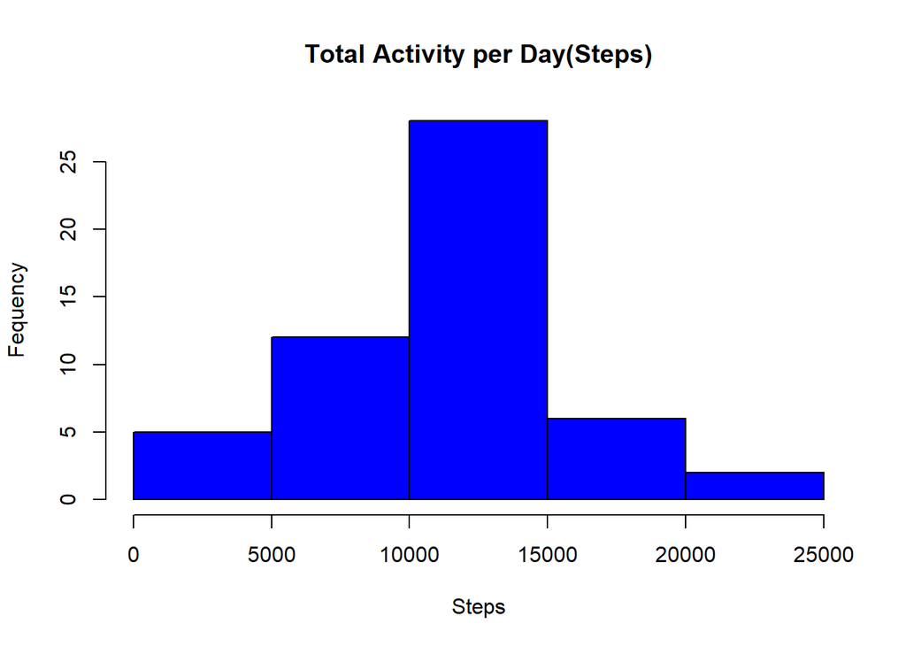

```r
hist(x = Combined$steps, xlab = "Steps", ylab = "Fequency", main = "Total Activity per Day(Steps)", col = "blue")
```

### Calculate and report the mean and median of the total number of steps taken per day

```r
Combined2 <- Combined %>% select(-interval)

summary(Combined2)
```

[output not shown]

#### Make a time series plot (i.e. type = “l”) of the 5-minute interval (x-axis) and the average number of steps taken, averaged across all days (y-axis)

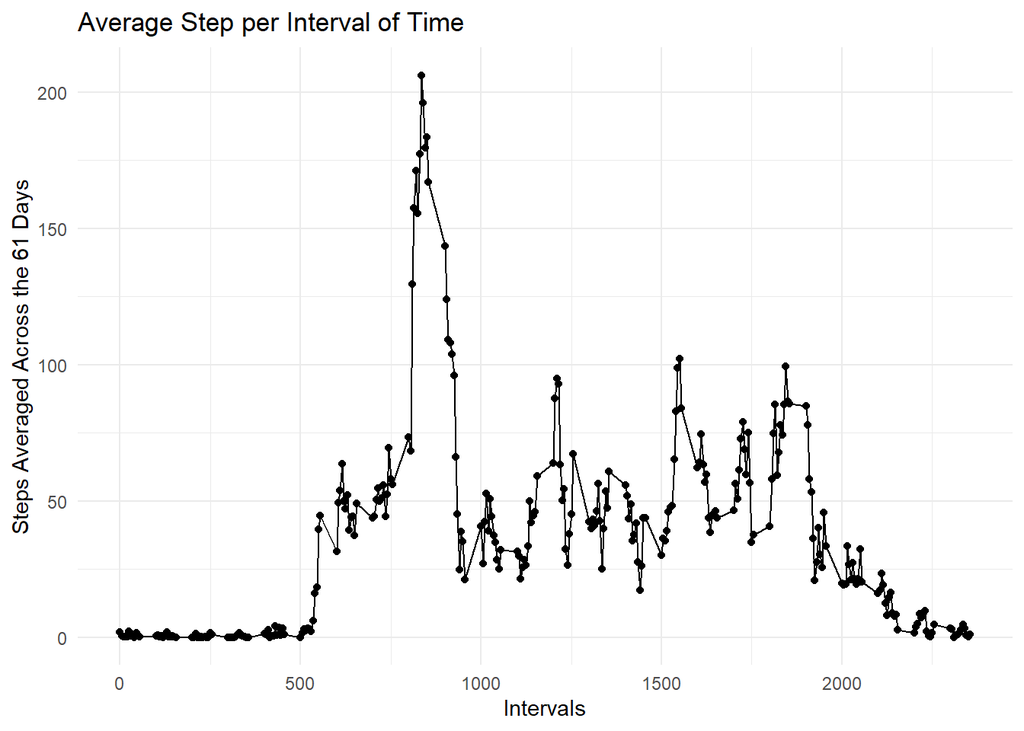

```r
library(ggplot2)
intervals <- activity %>%
  group_by(interval) %>%
  summarise(across(where(is.numeric), mean, na.rm = TRUE))
ggplot(intervals, aes(x = interval, y = steps)) +
  geom_line() +
  geom_point() +
  labs(title = "Average Step per Interval of Time", x = "Intervals", y = "Steps Averaged Across the 61 Days") +
  theme_minimal()
```

#### Which 5-minute interval, on average across all the days in the dataset, contains the maximum number of steps?

```r
max_step_mean <- intervals %>%
  filter(steps == max(steps))


print(max_step_mean)
```